# ABCD day-of-year and cognition

Bart Larsen

2023-03-15

# ABCD Data

## All ABCD factors

Here we apply the analysis pipeline to all the factors from ABCD.  
The following blocks of code fit the models and make tables of fit stats and then make plots.

### Whole sample

Fit the models for each factor across the whole sample.

#### Monthly variation

Figure S1A. Cognition varies by month of the year.

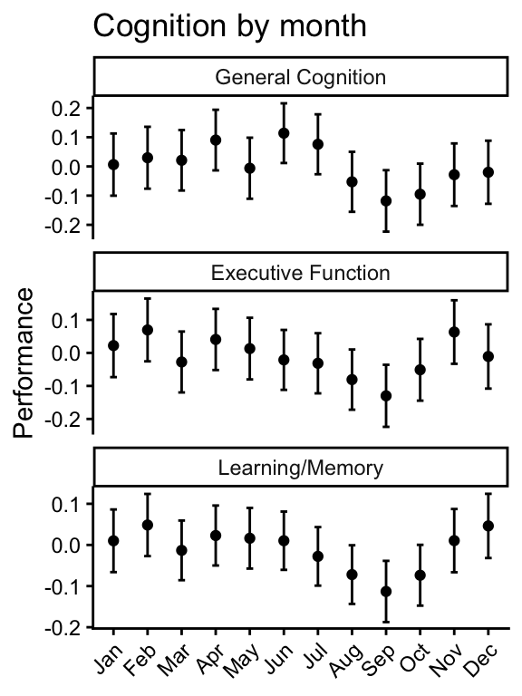

#### End of summer (end of summer break) vs spring (before summer break)

Figure S1B. Cognition is higher in spring (before summer break) than in late summer (after summer break). Response to reviewer comment.

| Factor | term | estimate | std.error | p.value | Eta2_partial |
| --- | --- | --- | --- | --- | --- |
| General Cognition | time_groupEnd of Summer | -0.1340609 | 0.0351850 | 0.0001435 | 0.0080002 |
| Executive Function | time_groupEnd of Summer | -0.1266928 | 0.0357854 | 0.0004097 | 0.0068963 |
| Learning/Memory | time_groupEnd of Summer | -0.1248444 | 0.0327352 | 0.0001415 | 0.0080342 |

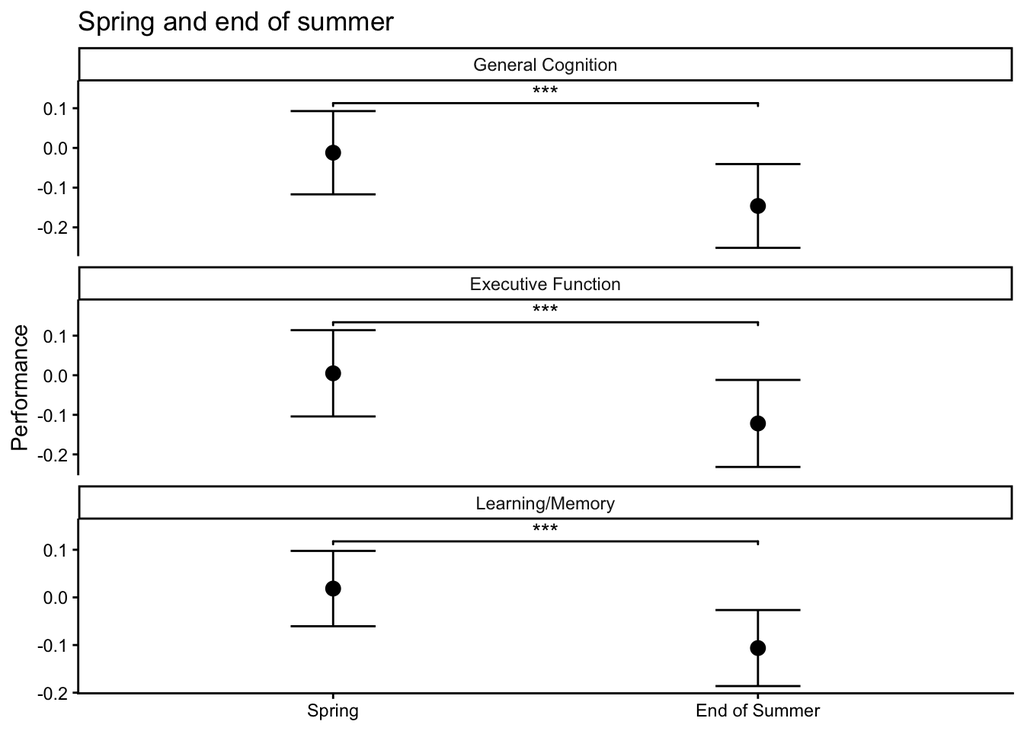

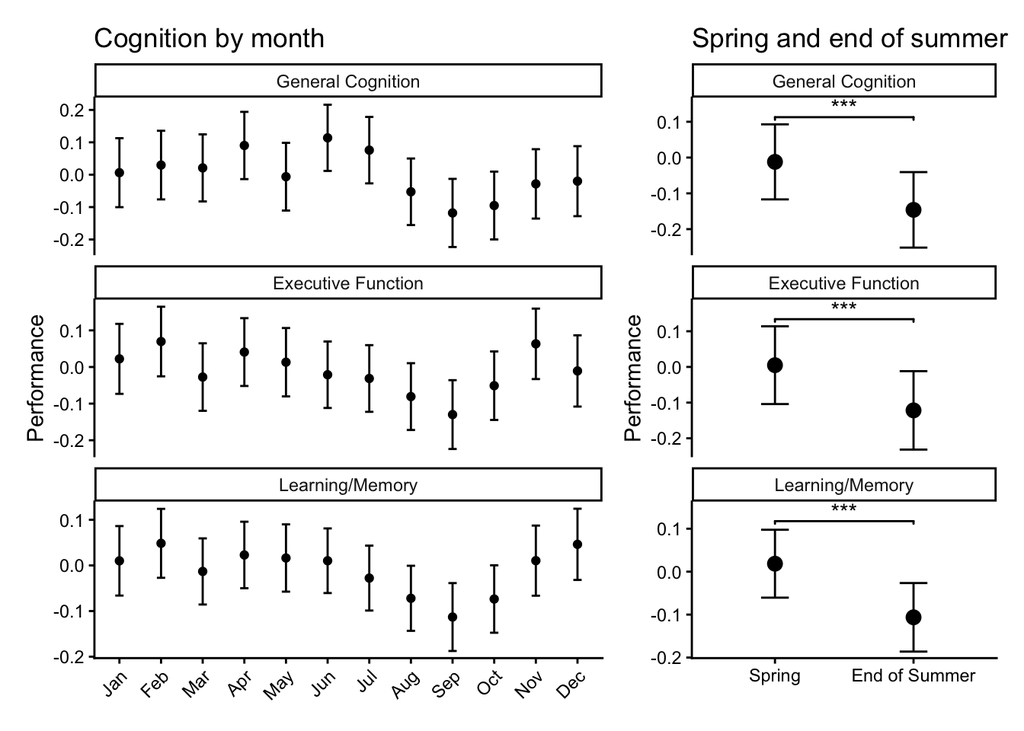

### Cyclical GAM analyses

Fit day-of-year as a cyclical smoothing function.

| Factor | term | N | edf | ref.df | statistic | p.value | pfdr |
| --- | --- | --- | --- | --- | --- | --- | --- |
| General Cognition | s(doy) | 11040 | 8.585359 | 50 | 2.2028041 | 0 | 0 |
| Executive Function | s(doy) | 11040 | 5.605465 | 50 | 0.9142870 | 0 | 0 |
| Learning/Memory | s(doy) | 11040 | 4.433673 | 50 | 0.6273772 | 0 | 0 |

| Factor | partialr2 |
| --- | --- |
| General Cognition | 0.0258947 |
| Executive Function | 0.0143190 |
| Learning/Memory | 0.0130297 |

#### Plot results

Now plot the ToY effect and plot the day of minimum performance on a polar plot.  
Figure 1A, top.

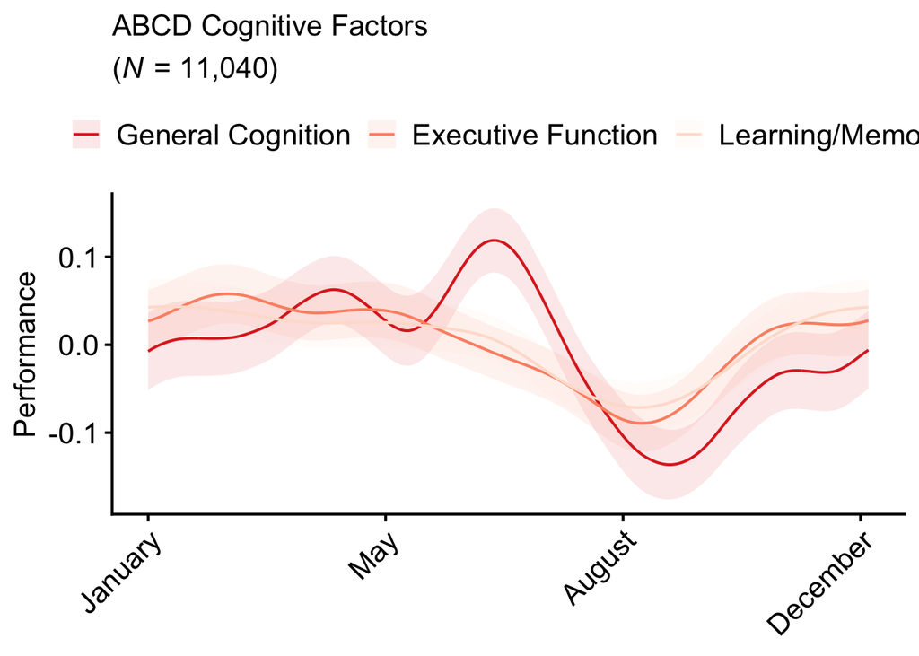

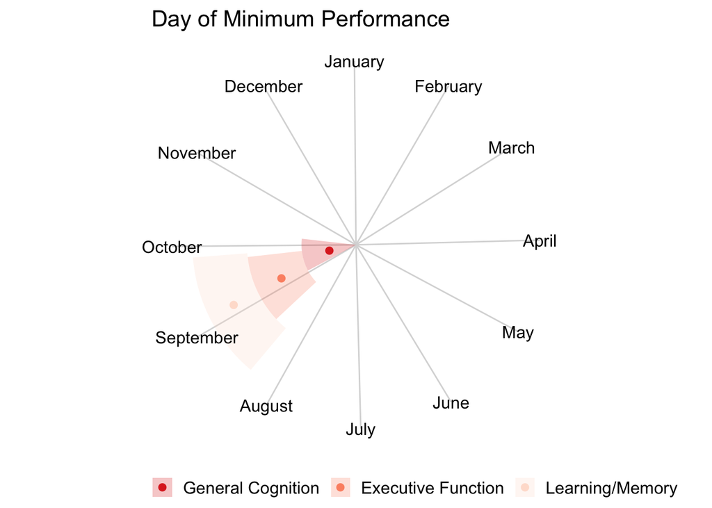

Confirm it family id is not influencing the results (excluding siblings from the analysis).

| Factor | term | N | edf | ref.df | statistic | p.value | pfdr |
| --- | --- | --- | --- | --- | --- | --- | --- |
| General Cognition | s(doy) | 7335 | 6.882977 | 50 | 0.9508517 | 0.0e+00 | 0.00e+00 |
| Executive Function | s(doy) | 7335 | 3.219659 | 50 | 0.4557846 | 8.2e-06 | 1.64e-05 |
| Learning/Memory | s(doy) | 7335 | 3.560302 | 50 | 0.3972612 | 3.7e-05 | 3.70e-05 |

| Factor | partialr2 |
| --- | --- |
| General Cognition | 0.0288786 |
| Executive Function | 0.0097785 |
| Learning/Memory | 0.0150798 |

Whole Sample

| Factor | N | edf | partialr2 | p.value | pfdr |
| --- | --- | --- | --- | --- | --- |
| General Cognition | 11040 | 8.585359 | 0.02589473 | 0 | 0 |
| Executive Function | 11040 | 5.605465 | 0.01431896 | 0 | 0 |
| Learning/Memory | 11040 | 4.433673 | 0.01302970 | 0 | 0 |

Whole Sample (No Siblings)

| Factor | N | edf | partialr2 | p.value | pfdr |
| --- | --- | --- | --- | --- | --- |
| General Cognition | 7335 | 6.882977 | 0.028878624 | 0.000000e+00 | 0.000000e+00 |
| Executive Function | 7335 | 3.219659 | 0.009778504 | 8.223994e-06 | 1.644799e-05 |
| Learning/Memory | 7335 | 3.560301 | 0.015079831 | 3.697913e-05 | 3.697913e-05 |

### Split-half replication

This code just repeats what we did for the whole sample for two demographically match splits (the ARMS).  
Fit the models, get fit stats, and make plots.

Model output for splits and factors

| matched_group | Factor | term | N | edf | ref.df | statistic | p.value | pfdr |
| --- | --- | --- | --- | --- | --- | --- | --- | --- |
| 1 | General Cognition | s(doy) | 5366 | 6.006393 | 50 | 0.5584359 | 0.0000101 | 0.0000202 |
| 1 | Executive Function | s(doy) | 5366 | 2.221274 | 50 | 0.1431961 | 0.0174287 | 0.0174287 |
| 1 | Learning/Memory | s(doy) | 5366 | 3.897552 | 50 | 0.6013638 | 0.0000002 | 0.0000005 |
| 2 | General Cognition | s(doy) | 5320 | 3.200391 | 50 | 0.3401098 | 0.0000251 | 0.0000502 |
| 2 | Executive Function | s(doy) | 5320 | 3.131552 | 50 | 0.5926489 | 0.0000004 | 0.0000011 |
| 2 | Learning/Memory | s(doy) | 5320 | 2.885010 | 50 | 0.2463411 | 0.0008706 | 0.0008706 |

Model partial r-squared

| matched_group | Factor | partialr2 |
| --- | --- | --- |
| 1 | General Cognition | 0.0263669 |
| 1 | Executive Function | 0.0157344 |
| 1 | Learning/Memory | 0.0226213 |
| 2 | General Cognition | 0.0303138 |
| 2 | Executive Function | 0.0168634 |
| 2 | Learning/Memory | 0.0118939 |

#### Plot abcd factor results for each ARM split

Do the plotting for each ARM split.  
Supplementary Figure 2.

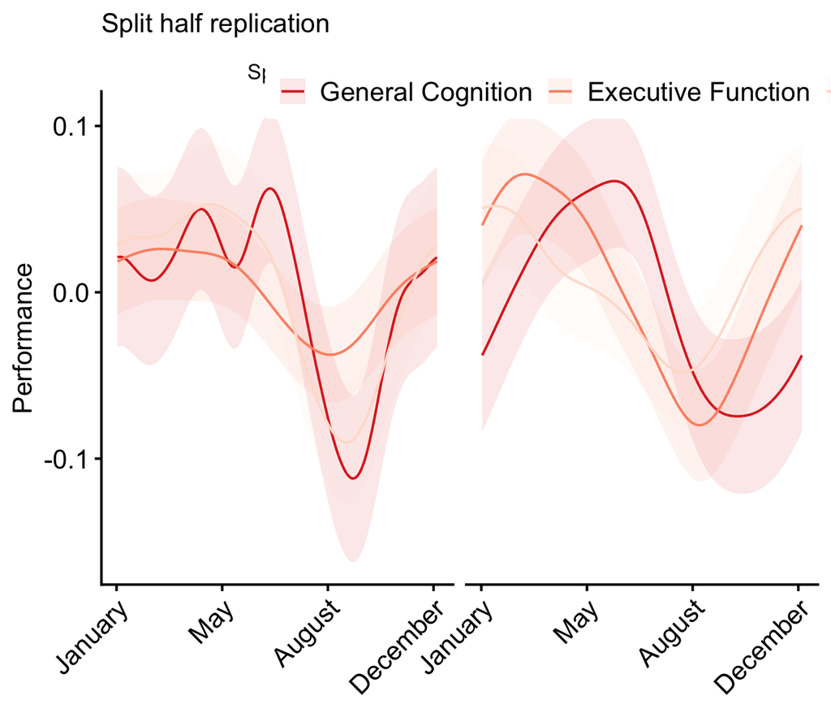

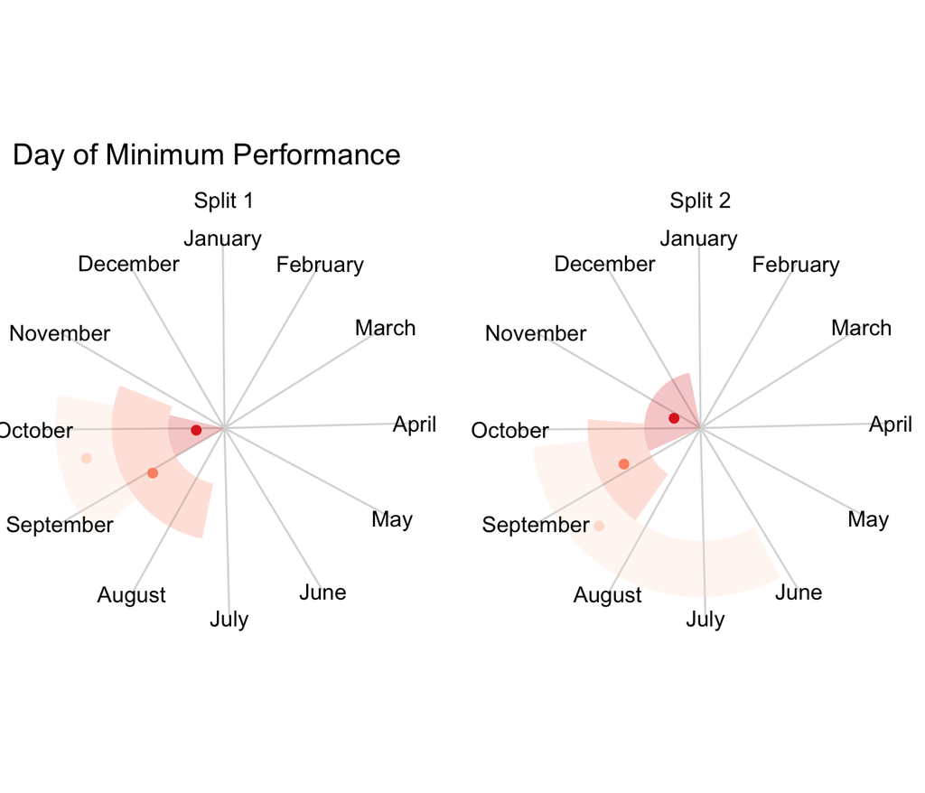

#### Random splits

Re-fit the models for n=20 random splits of the data.

Model output for random splits and factors

[output not shown]

#### Plot the random splits

Figure 1A bottom.

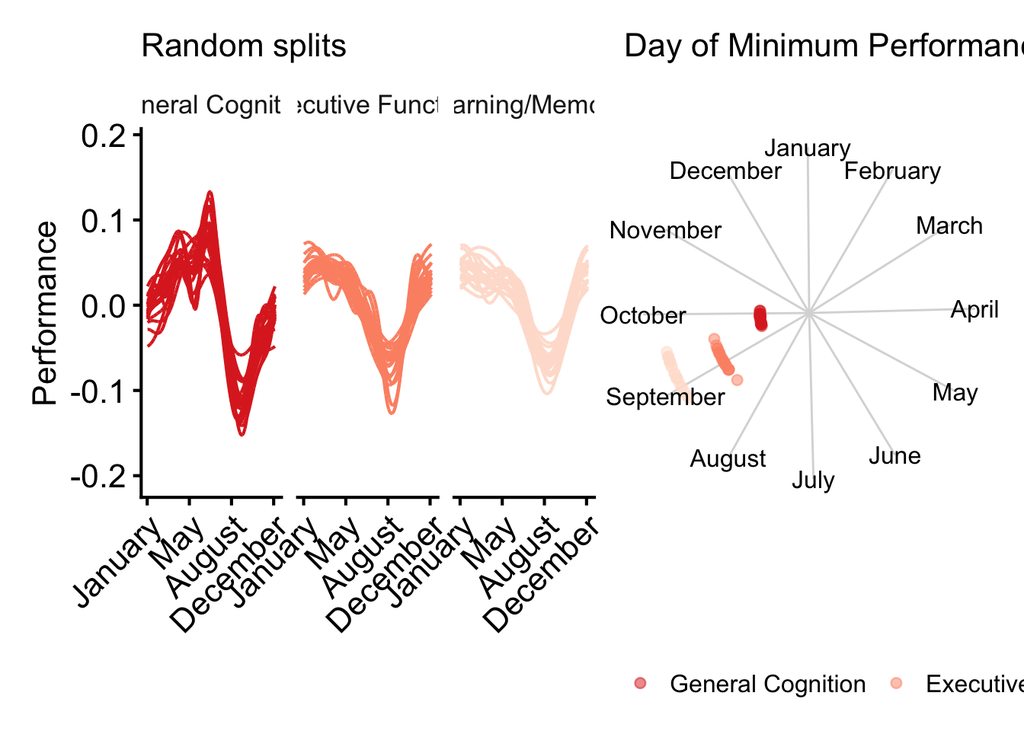

## Demographics

Examine how the effect of calendar day varies by demographic variables.

### Sex

```
##
## Family: gaussian
## Link function: identity
##
## Formula:
## neurocog_pc1.bl ~ s(weekdaynum, bs = "cc", k = 7) + osex + s(age,
##     k = 4) + s(doy, bs = "cc", k = 52) + s(doy, abcd_site, bs = "fs",
##     xt = list(bs = "cc")) + s(doy, osex, bs = "sz", xt = list(bs = "cc"))
##
## Parametric coefficients:
##              Estimate Std. Error t value Pr(>|t|)
## (Intercept)  0.018770   0.045764   0.410    0.682
## osex.L      -0.056753   0.009763  -5.813  6.3e-09 ***
## ---
## Signif. codes:  0 '***' 0.001 '**' 0.01 '*' 0.05 '.' 0.1 ' ' 1
##
## Approximate significance of smooth terms:
##                       edf  Ref.df       F p-value
## s(weekdaynum)     0.01727   5.000   0.001   0.776
## s(age)            2.26407   2.630 272.360  <2e-16 ***
## s(doy)            8.30500  50.000   1.067  <2e-16 ***
## s(doy,abcd_site) 57.43130 195.000   5.116  <2e-16 ***
## s(doy,osex)       1.43405   2.113   1.321   0.259
## ---
## Signif. codes:  0 '***' 0.001 '**' 0.01 '*' 0.05 '.' 0.1 ' ' 1
##
## Rank: 266/267
## R-sq.(adj) =  0.149   Deviance explained = 15.4%
## -REML =  12108  Scale est. = 0.51609   n = 11040
```

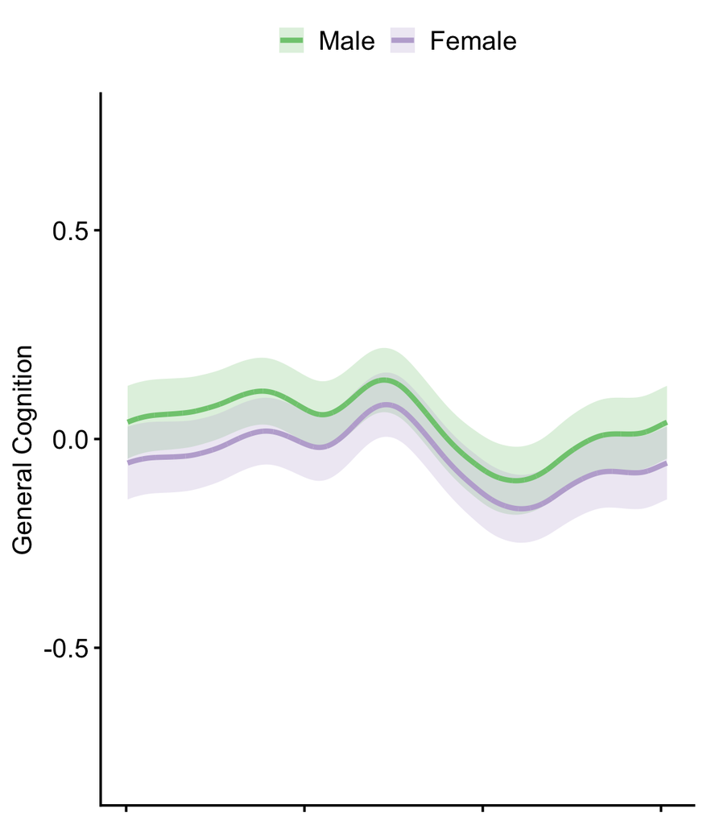

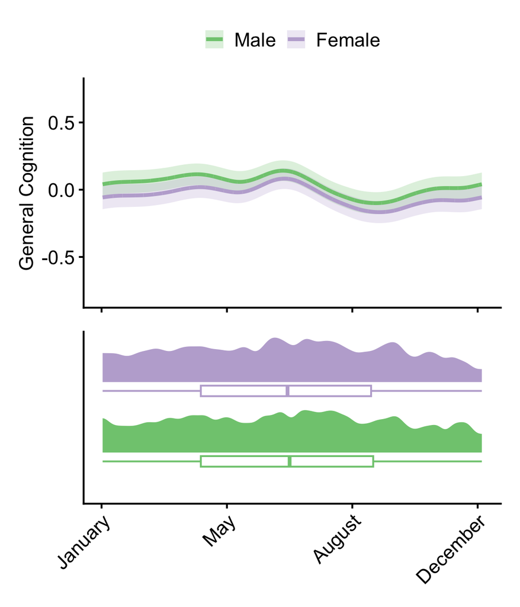

### Education

```
##
## Family: gaussian
## Link function: identity
##
## Formula:
## neurocog_pc1.bl ~ s(weekdaynum, bs = "cc", k = 7) + s(age, k = 4) +
##     s(doy, bs = "cc", k = 52) + s(doy, abcd_site, bs = "fs",
##     xt = list(bs = "cc")) + osex + oeduc + s(doy, oeduc, bs = "sz",
##     xt = list(bs = "cc", k = 52))
##
## Parametric coefficients:
##              Estimate Std. Error t value Pr(>|t|)
## (Intercept) -0.194838   0.031211  -6.243 4.46e-10 ***
## osex.L      -0.053429   0.008809  -6.066 1.36e-09 ***
## oeduc.L      0.622678   0.014934  41.697  < 2e-16 ***
## oeduc.Q      0.510800   0.016565  30.837  < 2e-16 ***
## oeduc.C     -0.374797   0.020956 -17.885  < 2e-16 ***
## oeduc^4     -0.071727   0.021265  -3.373 0.000746 ***
## ---
## Signif. codes:  0 '***' 0.001 '**' 0.01 '*' 0.05 '.' 0.1 ' ' 1
##
## Approximate significance of smooth terms:
##                        edf  Ref.df       F  p-value
## s(weekdaynum)     0.007824   5.000   0.001    0.418
## s(age)            1.016823   1.033 853.479  < 2e-16 ***
## s(doy)            4.827198  50.000   0.435 1.52e-06 ***
## s(doy,abcd_site) 44.481288 195.000   2.641  < 2e-16 ***
## s(doy,oeduc)      2.789688   4.103   0.987    0.444
## ---
## Signif. codes:  0 '***' 0.001 '**' 0.01 '*' 0.05 '.' 0.1 ' ' 1
##
## Rank: 294/298
## R-sq.(adj) =    0.3   Deviance explained = 30.3%
## -REML =  10999  Scale est. = 0.42448   n = 11027
```

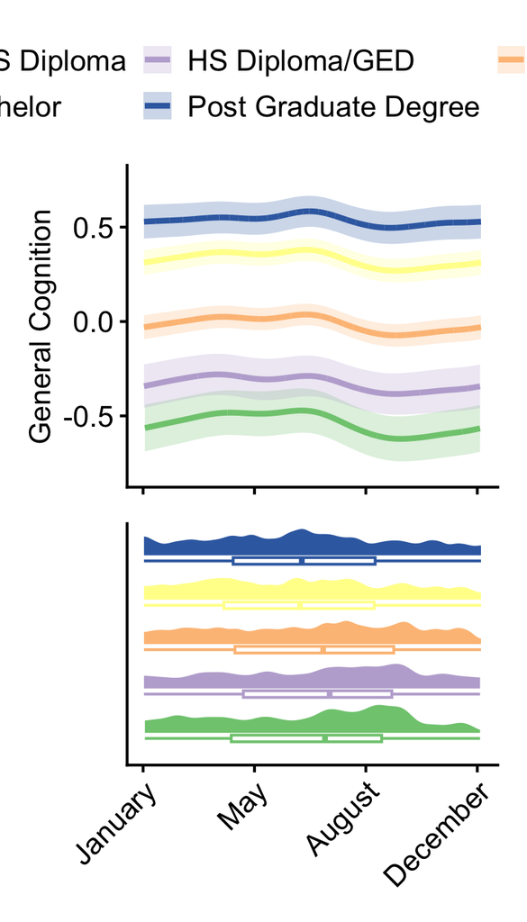

### Income

```
##
## Family: gaussian
## Link function: identity
##
## Formula:
## neurocog_pc1.bl ~ s(weekdaynum, bs = "cc", k = 7) + s(age, k = 4) +
##     s(doy, bs = "cc", k = 52) + s(doy, abcd_site, bs = "fs",
##     xt = list(bs = "cc")) + s(doy, household.income, bs = "sz",
##     xt = list(bs = "cc"))
##
## Parametric coefficients:
##             Estimate Std. Error t value Pr(>|t|)
## (Intercept) 0.003779   0.031218   0.121    0.904
##
## Approximate significance of smooth terms:
##                               edf  Ref.df       F p-value
## s(weekdaynum)            0.009366   5.000   0.001   0.491
## s(age)                   1.747590   2.115 365.791  <2e-16 ***
## s(doy)                   7.334550  50.000   0.674  <2e-16 ***
## s(doy,abcd_site)        44.030308 194.000   2.482  <2e-16 ***
## s(doy,household.income)  2.790324   3.324 506.237  <2e-16 ***
## ---
## Signif. codes:  0 '***' 0.001 '**' 0.01 '*' 0.05 '.' 0.1 ' ' 1
##
## R-sq.(adj) =  0.263   Deviance explained = 26.7%
## -REML =  10237  Scale est. = 0.43833   n = 10100
```

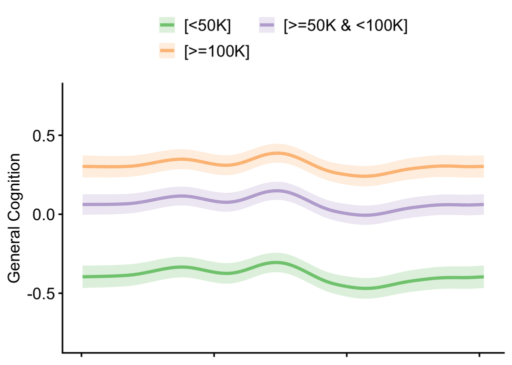

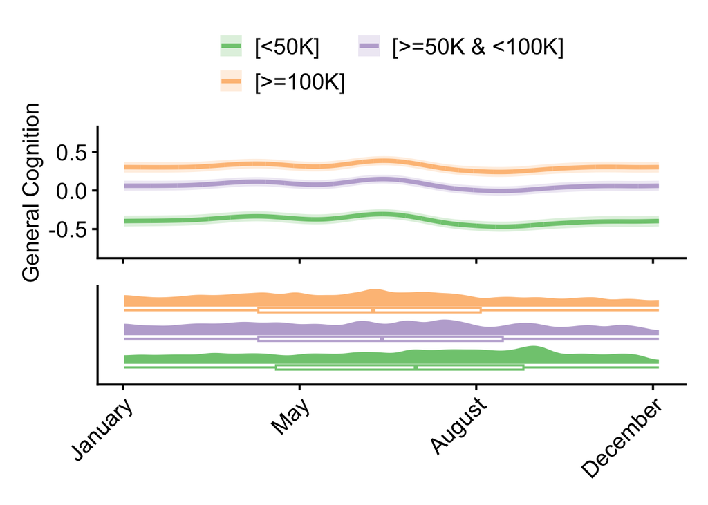

### Race

```
##
## Family: gaussian
## Link function: identity
##
## Formula:
## neurocog_pc1.bl ~ s(weekdaynum, bs = "cc", k = 7) + s(age, k = 4) +
##     s(doy, bs = "cc", k = 52) + s(doy, abcd_site, bs = "fs",
##     xt = list(bs = "cc")) + osex + orace.4level + s(doy, orace.4level,
##     bs = "sz", xt = list(bs = "cc", k = 52))
##
## Parametric coefficients:
##                  Estimate Std. Error t value Pr(>|t|)
## (Intercept)    -0.0007457  0.0387718  -0.019 0.984655
## osex.L         -0.0493163  0.0092968  -5.305 1.15e-07 ***
## orace.4level.L  0.0553077  0.0165064   3.351 0.000809 ***
## orace.4level.Q  0.1224603  0.0250725   4.884 1.05e-06 ***
## orace.4level.C -0.6202775  0.0321217 -19.310  < 2e-16 ***
## ---
## Signif. codes:  0 '***' 0.001 '**' 0.01 '*' 0.05 '.' 0.1 ' ' 1
##
## Approximate significance of smooth terms:
##                           edf  Ref.df       F  p-value
## s(weekdaynum)        0.002231   5.000   0.000    0.651
## s(age)               2.575508   2.865 271.170  < 2e-16 ***
## s(doy)               5.136662  50.000   0.487 1.53e-06 ***
## s(doy,abcd_site)    49.316889 195.000   3.229  < 2e-16 ***
## s(doy,orace.4level)  1.615643   2.332   1.672    0.185
## ---
## Signif. codes:  0 '***' 0.001 '**' 0.01 '*' 0.05 '.' 0.1 ' ' 1
##
## Rank: 285/288
## R-sq.(adj) =  0.229   Deviance explained = 23.3%
## -REML =  11383  Scale est. = 0.46659   n = 10888
```

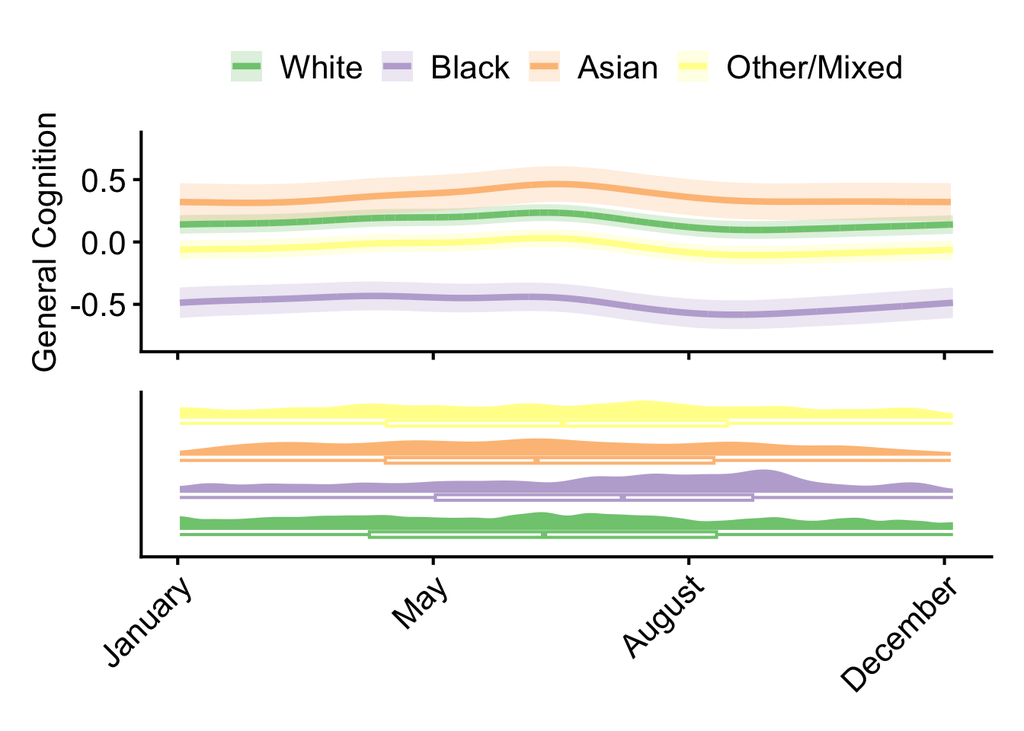

## Comparing the magnitude of day-of-year and age effects.

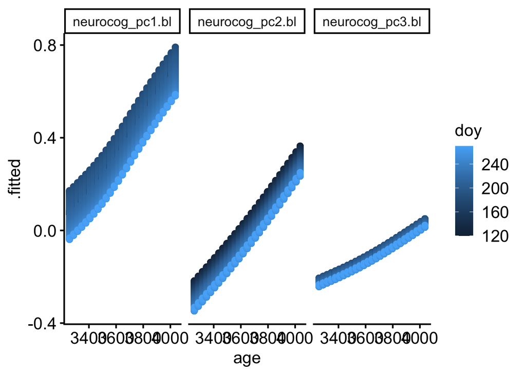

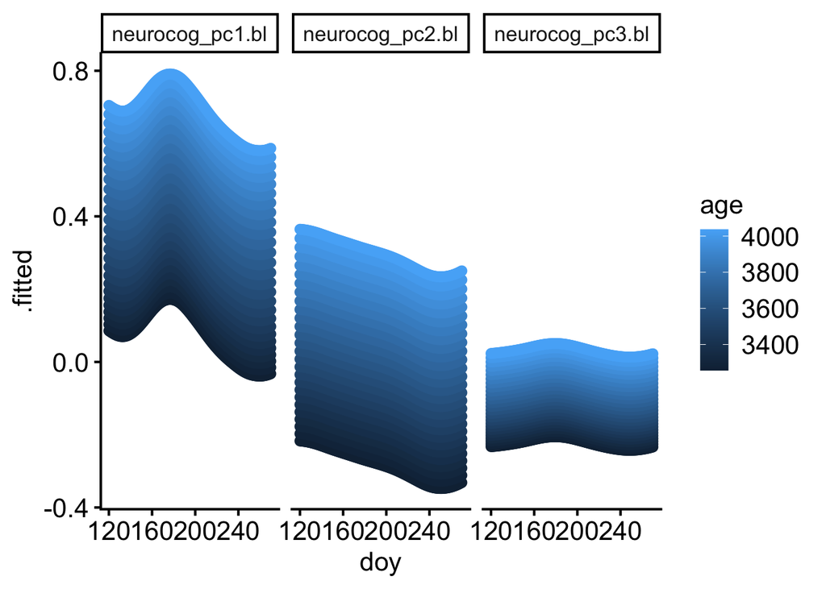

```
## Proportion of yearly age effect for summer months neurocog_pc1.bl = 0.92 [0.68, 1.18]
## Proportion of yearly age effect for summer months neurocog_pc2.bl = 0.53 [0.28, 0.86]
## Proportion of yearly age effect for summer months neurocog_pc3.bl = 1.00 [0.54, 1.51]
```

```
## Kids lose 4.94 days of development in neurocog_pc1.bl for each day of summer
## Kids lose 1.89 days of development in neurocog_pc2.bl for each day of summer
## Kids lose 4.41 days of development in neurocog_pc3.bl for each day of summer
```

### Repeat while covarying for exposome

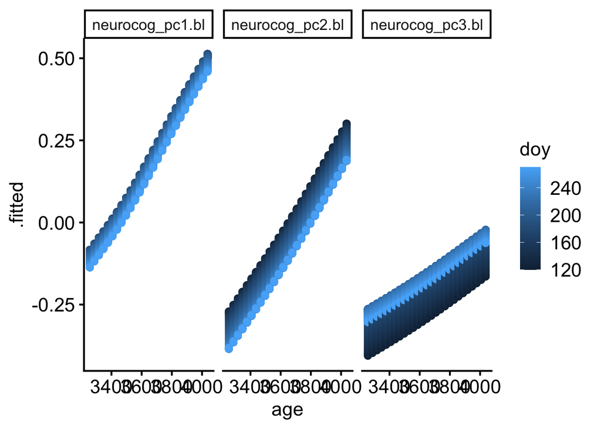

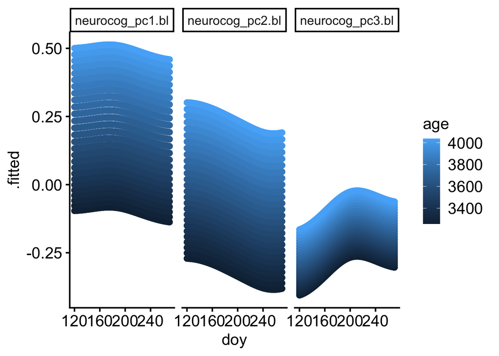

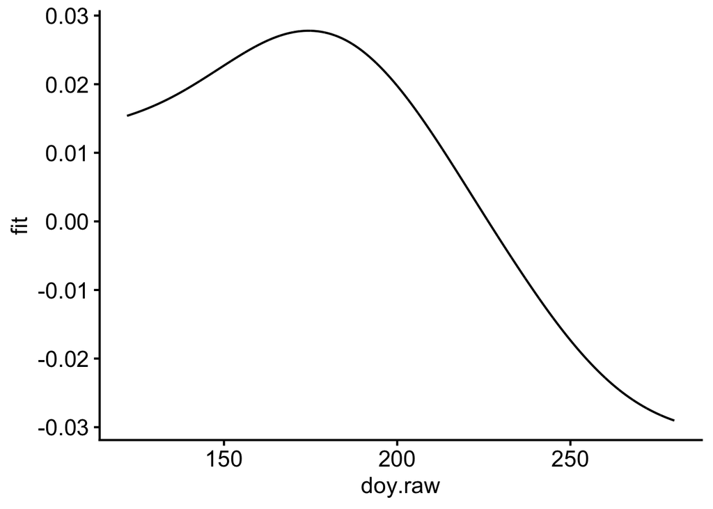

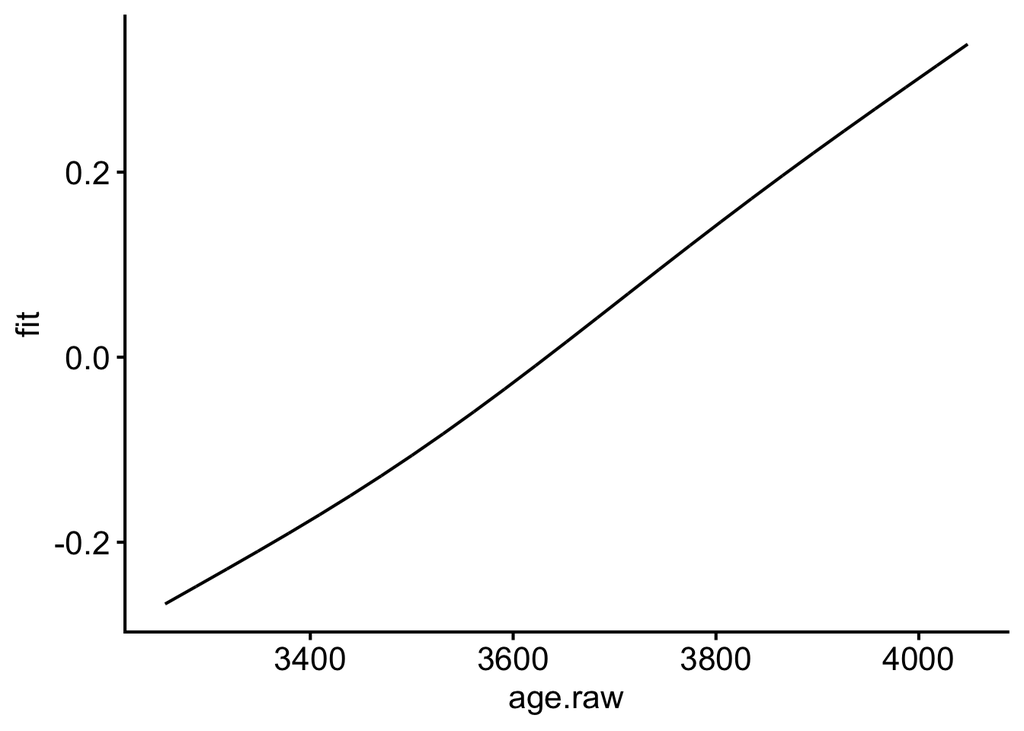

```
## Proportion of yearly age effect for neurocog_pc1.bl = 0.22 [0.08, 0.40]
## Proportion of yearly age effect for neurocog_pc2.bl = 0.29 [0.12, 0.47]
## Proportion of yearly age effect for neurocog_pc3.bl = 0.43 [0.15, 0.77]
```

```
## Kids lose 0.94 days of development in neurocog_pc1.bl for each day of summer
## Kids lose 1.05 days of development in neurocog_pc2.bl for each day of summer
## Kids lose 1.48 days of development in neurocog_pc3.bl for each day of summer
```

## Site effects

Extract model predicted minima for each ABCD site and plot them.

[figure not shown]

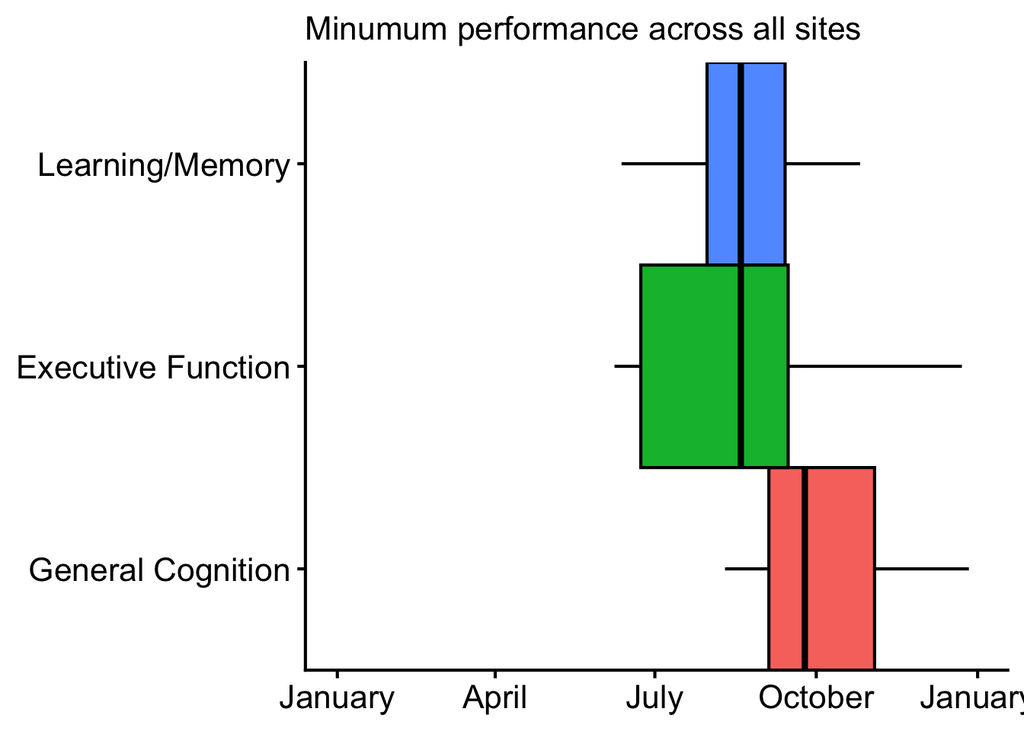

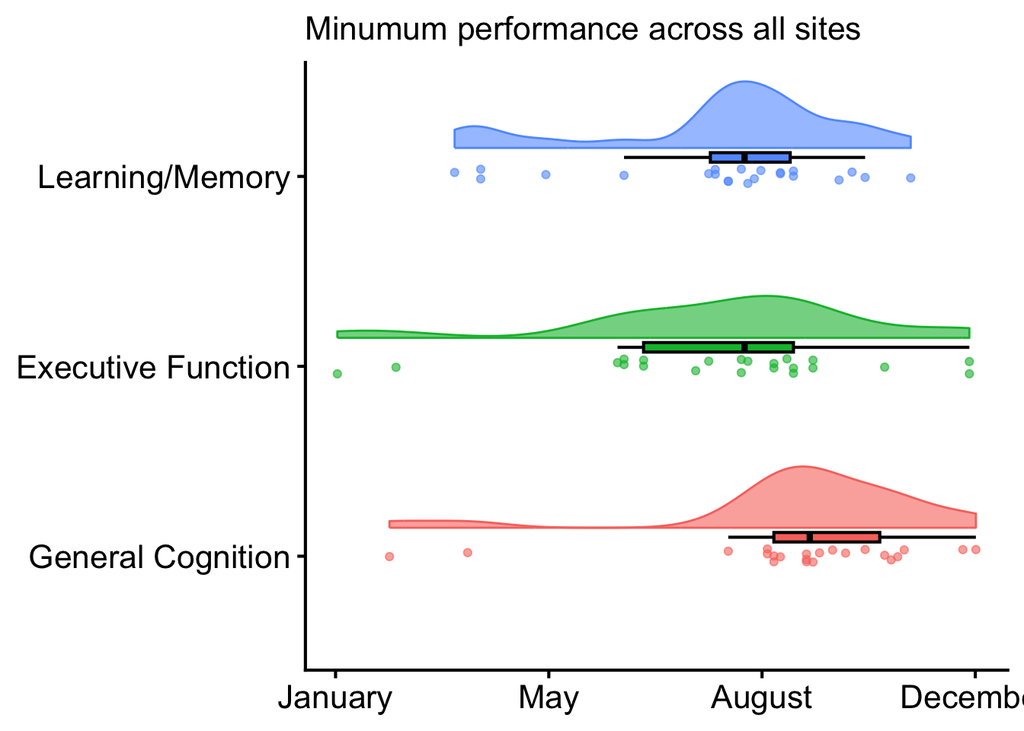

## All abcd tasks

Just repeating for every task. Now included in figure 1B.

| cogtest | term | N | edf | ref.df | statistic | p.value | pfdr |
| --- | --- | --- | --- | --- | --- | --- | --- |
| Card Sort | s(doy) | 11724 | 5.786522 | 50 | 1.1654624 | 0.0000000 | 0.0000000 |
| Crystallized Composite | s(doy) | 11697 | 6.942890 | 50 | 1.7168793 | 0.0000000 | 0.0000000 |
| Flanker | s(doy) | 11723 | 5.205273 | 50 | 0.5844558 | 0.0000046 | 0.0000093 |
| Fluid Composite | s(doy) | 11641 | 7.052312 | 50 | 1.1520117 | 0.0000000 | 0.0000000 |
| List Sorting | s(doy) | 11680 | 6.989193 | 50 | 1.6742637 | 0.0000000 | 0.0000000 |
| Pattern Comparison | s(doy) | 11705 | 3.242720 | 50 | 0.5541712 | 0.0000025 | 0.0000076 |
| Picture Sequence | s(doy) | 11717 | 3.013277 | 50 | 0.3017051 | 0.0002282 | 0.0002282 |
| Picture Vocabulary | s(doy) | 11729 | 6.594091 | 50 | 1.2996465 | 0.0000000 | 0.0000000 |
| Reading | s(doy) | 11715 | 5.481965 | 50 | 1.1751173 | 0.0000000 | 0.0000000 |
| Total Composite | s(doy) | 11637 | 8.259050 | 50 | 2.3729293 | 0.0000000 | 0.0000000 |

#### Plot abcd task results

Supplementary figure showing the results of the ABCD tasks.

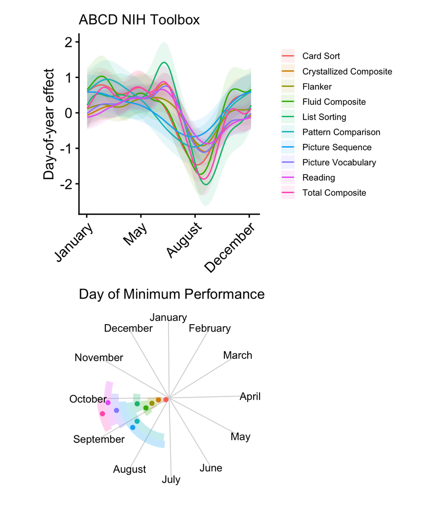

# PNC

Analyses for the PNC data.  
The difference between this analysis and the ABCD analysis is that we included an age*ToY interaction to allow the ToY effect to vary across the age range.

## All PNC factors

We fit the interaction model for doy and age for all factors and extract model fit stats.

| Factor | term | N | edf | ref.df | statistic | p.value | pfdr |
| --- | --- | --- | --- | --- | --- | --- | --- |
| NAR_F1_Social_Cognition_Efficiency | s(doy) | 9416 | 0.0088256 | 50 | 0.0001438 | 0.4442362 | 0.4442362 |
| NAR_F1_Social_Cognition_Efficiency | ti(age,doy) | 9416 | 13.0830761 | 72 | 0.5518481 | 0.0000032 | 0.0000291 |
| NAR_F2_Complex_Reasoning_Efficiency | s(doy) | 9416 | 1.1356844 | 50 | 0.0427887 | 0.1293539 | 0.2587077 |
| NAR_F2_Complex_Reasoning_Efficiency | ti(age,doy) | 9416 | 10.9243588 | 72 | 0.4587709 | 0.0000105 | 0.0000842 |
| NAR_F3_Executive_Efficiency | s(doy) | 9416 | 3.9826001 | 50 | 0.3562670 | 0.0003749 | 0.0022494 |
| NAR_F3_Executive_Efficiency | ti(age,doy) | 9416 | 7.4988913 | 72 | 0.2734035 | 0.0007222 | 0.0036110 |
| NAR_F4_Memory_Efficiency | s(doy) | 9416 | 2.3608617 | 50 | 0.2424502 | 0.0010400 | 0.0041598 |
| NAR_F4_Memory_Efficiency | ti(age,doy) | 9416 | 7.5407454 | 72 | 0.3102556 | 0.0001834 | 0.0012840 |
| NAR_Overall_Efficiency | s(doy) | 9416 | 2.5607255 | 50 | 0.1779134 | 0.0094973 | 0.0284920 |
| NAR_Overall_Efficiency | ti(age,doy) | 9416 | 11.9006157 | 72 | 0.5672552 | 0.0000008 | 0.0000077 |

| Factor | partialr2 |
| --- | --- |
| NAR_F1_Social_Cognition_Efficiency | 0.0055442 |
| NAR_F2_Complex_Reasoning_Efficiency | 0.0049108 |
| NAR_F3_Executive_Efficiency | 0.0054595 |
| NAR_F4_Memory_Efficiency | 0.0046590 |
| NAR_Overall_Efficiency | 0.0068493 |

#### Plot PNC factors

Generate plots for the above models to visualize the predicted performance across the year.

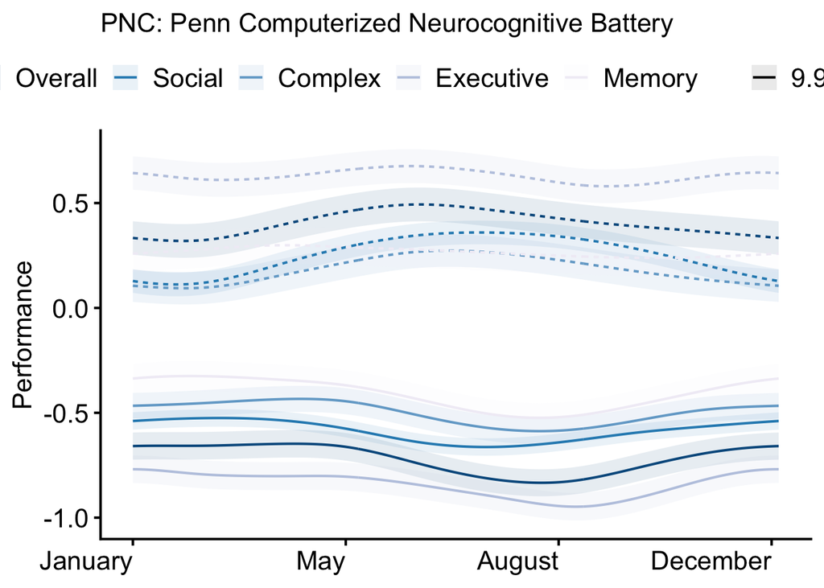

# ADHD 1000

```
## [1] "Number of unique ADHD-1000 participants: 843"
```

```
## [1] "Number of ADHD-1000 observations: 2454"
```

### All tasks: group*doy effect

| cog.scale | term | N | edf | ref.df | statistic | p.value | p.fdr |
| --- | --- | --- | --- | --- | --- | --- | --- |
| Color-Word Interference | s(doy) | 1805 | 1.0922356 | 50 | 0.1097764 | 0.1614519 | 0.4843556 |
| Color-Word Interference | s(doy):oADHD_StatusADHD | 1805 | 0.0001011 | 11 | 0.0000013 | 0.9364048 | 0.9364048 |
| Color-Word Interference | ti(interview_age,doy) | 1805 | 5.3396175 | 99 | 0.5961082 | 0.0000641 | 0.0003845 |
| Trails B | s(doy) | 2035 | 0.0000687 | 50 | 0.0000010 | 0.4426471 | 0.6639707 |
| Trails B | s(doy):oADHD_StatusADHD | 2035 | 0.5247357 | 11 | 0.1073694 | 0.2762318 | 0.8286953 |
| Trails B | ti(interview_age,doy) | 2035 | 6.5084485 | 99 | 0.1768185 | 0.0355039 | 0.0426047 |
| 2-Back | s(doy) | 2211 | 0.0000641 | 50 | 0.0000005 | 0.7458386 | 0.7458386 |
| 2-Back | s(doy):oADHD_StatusADHD | 2211 | 0.0000460 | 11 | 0.0000011 | 0.8180566 | 0.9364048 |
| 2-Back | ti(interview_age,doy) | 2211 | 0.0002354 | 99 | 0.0000017 | 0.7899985 | 0.7899985 |
| Spatial Span | s(doy) | 2404 | 0.0001337 | 50 | 0.0000020 | 0.4075093 | 0.6639707 |
| Spatial Span | s(doy):oADHD_StatusADHD | 2404 | 1.1775249 | 11 | 0.2840396 | 0.1482377 | 0.8286953 |
| Spatial Span | ti(interview_age,doy) | 2404 | 9.4759663 | 99 | 0.2613824 | 0.0077111 | 0.0221812 |
| Stop-Go RT | s(doy) | 2362 | 0.0001200 | 50 | 0.0000011 | 0.6654926 | 0.7458386 |
| Stop-Go RT | s(doy):oADHD_StatusADHD | 2362 | 0.0000594 | 11 | 0.0000034 | 0.5394729 | 0.9364048 |
| Stop-Go RT | ti(interview_age,doy) | 2362 | 5.8469055 | 99 | 0.1587871 | 0.0328399 | 0.0426047 |
| CPT D’ | s(doy) | 2331 | 4.4296455 | 50 | 1.5368343 | 0.0006857 | 0.0041140 |
| CPT D’ | s(doy):oADHD_StatusADHD | 2331 | 0.0002887 | 11 | 0.0000076 | 0.8023759 | 0.9364048 |
| CPT D’ | ti(interview_age,doy) | 2331 | 4.7713590 | 99 | 0.1922313 | 0.0110906 | 0.0221812 |

#### Plot (supplement)

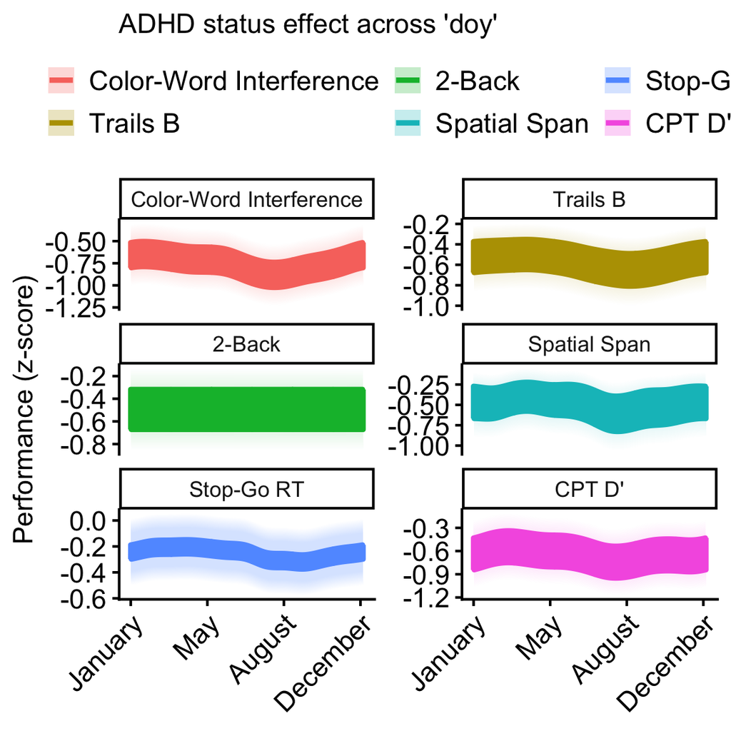

#### Radial plots

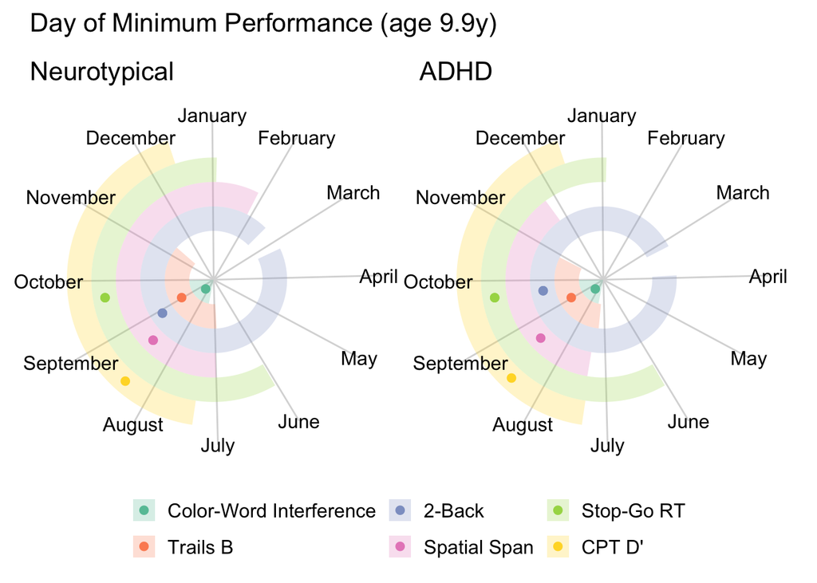

### PCA: Overall Performance

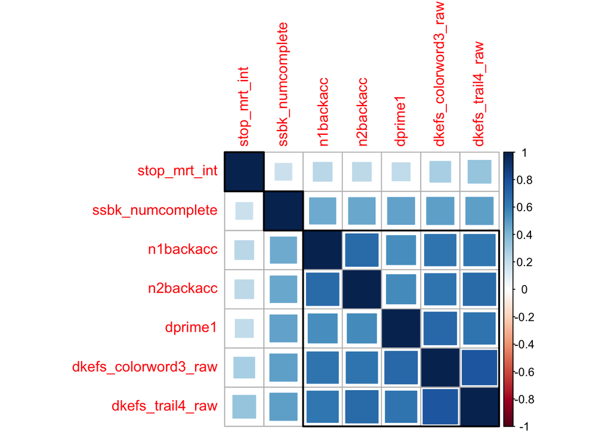

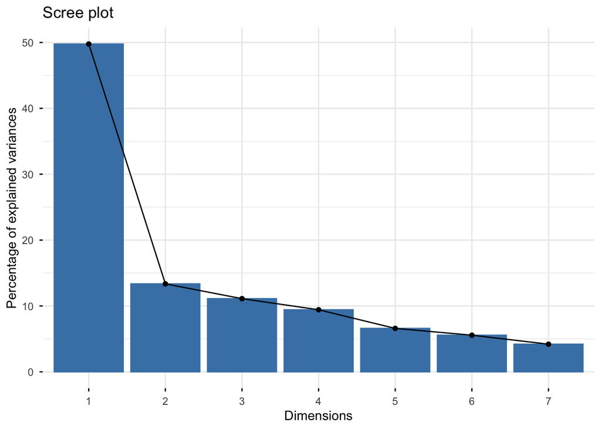

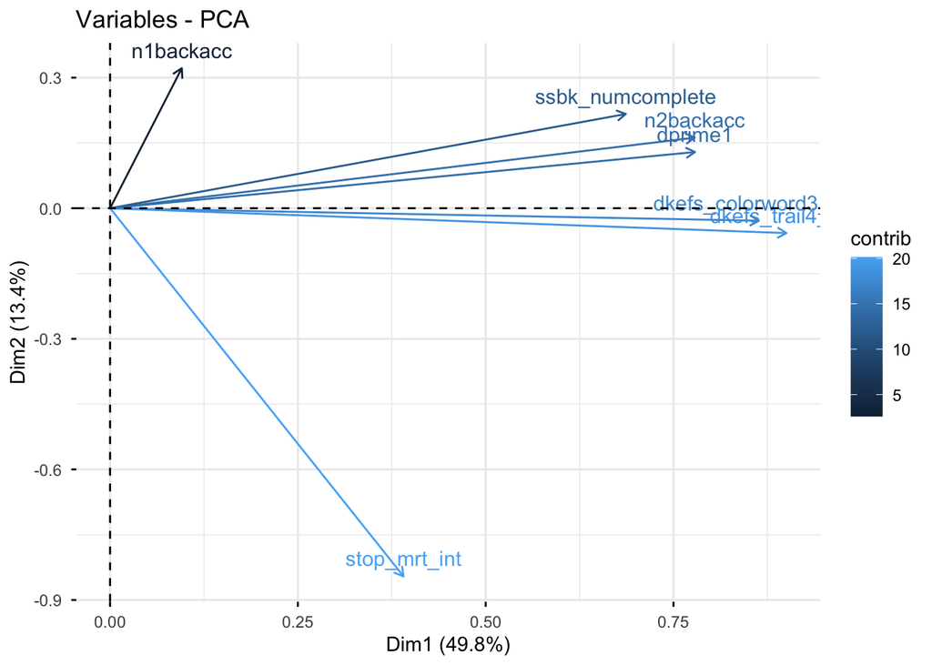

```
##
## Family: gaussian
## Link function: identity
##
## Formula:
## PC1 ~ s(interview_age) + s(weekdaynum, bs = "cc", k = 6) + visit_year +
##     s(doy, bs = "cc", k = 52) + ti(interview_age, doy, bs = c("tp",
##     "cc"), k = c(10, 13)) + ADHD_Status + s(doy, by = oADHD_Status,
##     k = 26) + s(src_subject_id, bs = "re") + sex
##
## Parametric coefficients:
##                 Estimate Std. Error t value Pr(>|t|)
## (Intercept)      0.97153    0.11269   8.621   <2e-16 ***
## visit_year.L     0.43252    0.37769   1.145   0.2526
## visit_year.Q     0.04665    0.33916   0.138   0.8907
## visit_year.C     0.03981    0.20844   0.191   0.8486
## visit_year^4     0.21026    0.32452   0.648   0.5173
## visit_year^5     0.14388    0.16256   0.885   0.3765
## visit_year^6    -0.39567    0.32417  -1.221   0.2228
## visit_year^7    -0.14220    0.16435  -0.865   0.3873
## visit_year^8     0.28122    0.35724   0.787   0.4315
## visit_year^9    -0.13170    0.14422  -0.913   0.3615
## visit_year^10   -0.18321    0.44958  -0.408   0.6838
## ADHD_StatusADHD -0.79221    0.07143 -11.091   <2e-16 ***
## sexM             0.17630    0.07945   2.219   0.0269 *
## ---
## Signif. codes:  0 '***' 0.001 '**' 0.01 '*' 0.05 '.' 0.1 ' ' 1
##
## Approximate significance of smooth terms:
##                               edf  Ref.df      F p-value
## s(interview_age)        4.639e+00   5.494 99.196  <2e-16 ***
## s(weekdaynum)           6.665e-03   4.000  0.002  0.3504
## s(doy)                  1.836e+00  50.000  0.324  0.0706 .
## ti(interview_age,doy)   9.316e+00  99.000  0.388  0.0234 *
## s(doy):oADHD_StatusADHD 3.070e+00   3.575  1.452  0.2680
## s(src_subject_id)       5.023e+02 723.000  2.562  <2e-16 ***
## ---
## Signif. codes:  0 '***' 0.001 '**' 0.01 '*' 0.05 '.' 0.1 ' ' 1
##
## R-sq.(adj) =  0.884   Deviance explained =   94%
## fREML = 1529.7  Scale est. = 0.3946    n = 1096
```

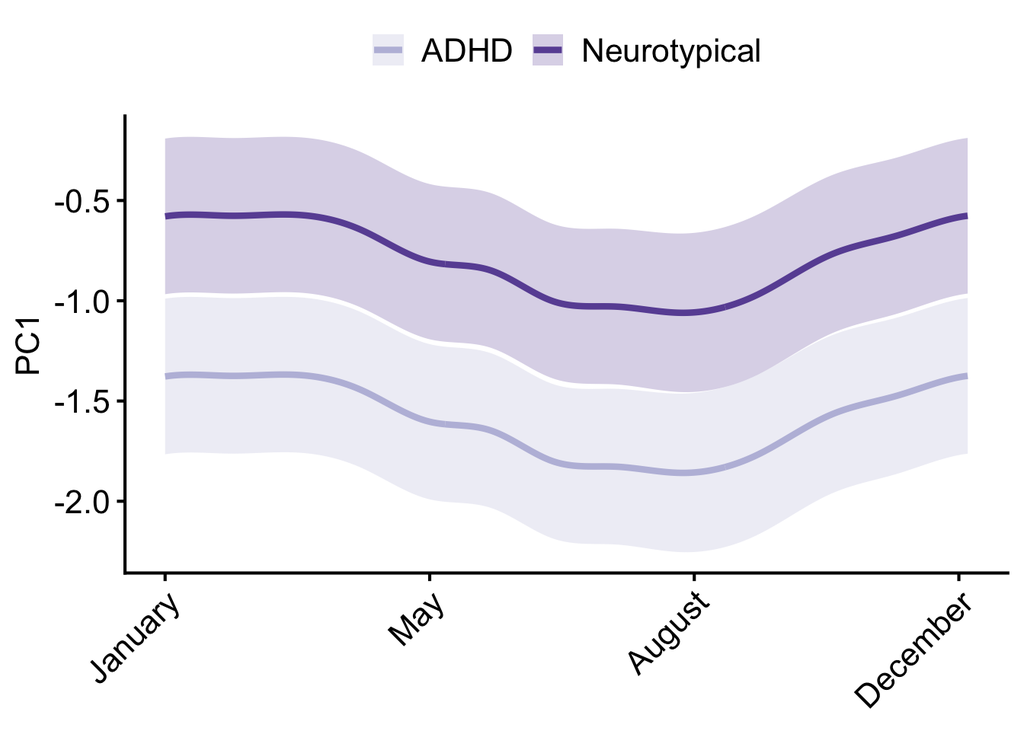

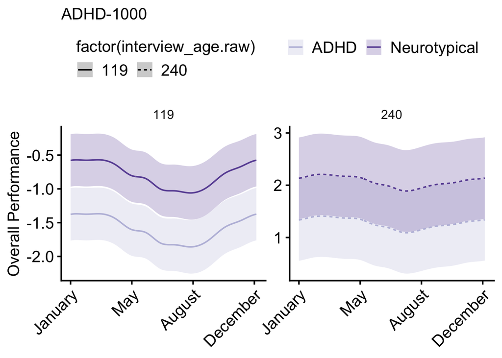